# 2023-12-23-(R) 밀도함수와 히스토그램 그리기

# 정규분포 함수 그리기, 값 계산하기

## 1. 표준점수의 밀도함수를 그려보세요.

> 표준점수는 m = 30 , sd = 5 인 정규분포를 따른다.

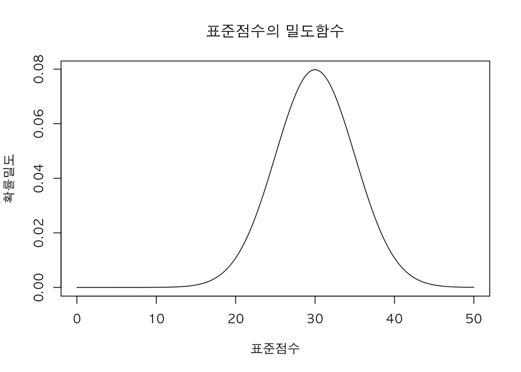

```r
x = seq(0,50,0.1)
y = dnorm(x, 30,5)
plot(x,y, type = 'l', xlab = '표준점수', ylab = '확률밀도', main = '표준점수의 밀도함수')
```

## 2. 임의로 1명을 선택하여 통계 점수를 조회했을떄 45점 보다 높은 점수를 받았을 확률

```r
(1-pnorm(45, 30, 5))*100
```

```
## [1] 0.1349898
```

## 3. 상위 10% 점수를 받았을때 해당 점수는?

```r
qnorm(0.9 ,mean = 30, sd=5)
```

```
## [1] 36.40776
```

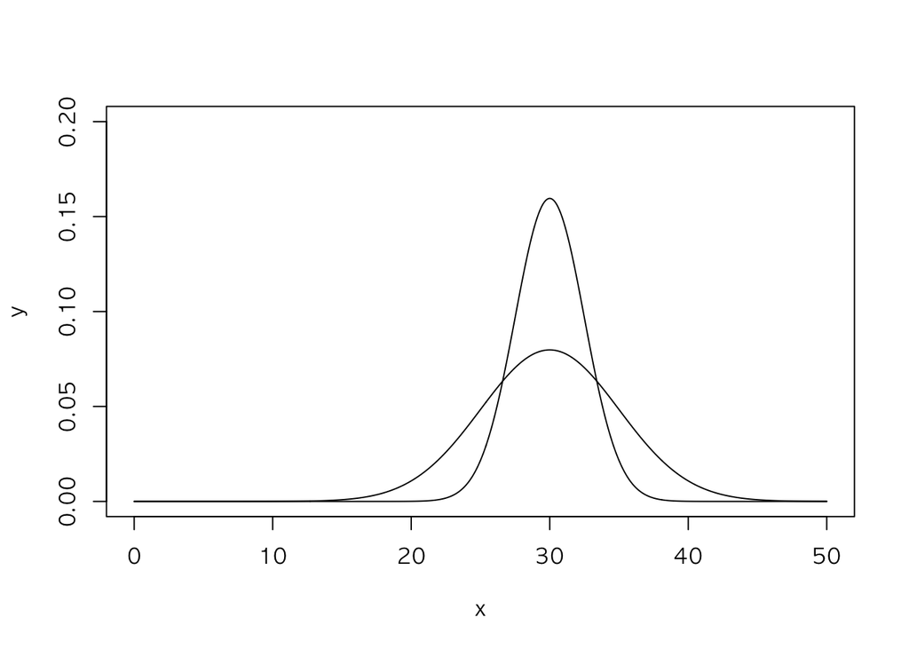

```r
x = seq(0,50,0.1)
y = dnorm(x, 30,5)
plot(x,y, type = 'l', ylim = c(0, 0.2))
x2 <- seq(0,50,0.1)
y2 <- dnorm(x, 30, 5/2)
lines(x2,y2)
```

## 5. 수강생의 통계점수의 평균을 내었을떄, 이 값이 38 점보다 높게 나올 확률

```r
(1-pnorm(38, 30, 5/2)) *100
```

```
## [1] 0.06871379
```

# 카이제곱분포 함수 그리기, 값 계산하기

## 1. 자유도가 4인 카이제곱 분포의 확률밀도함수를 그려보세요.

dchisq, pchisq, qchisq, rchisq  
카이제곱 분포는 정의역이 0보다 크거나 같다.

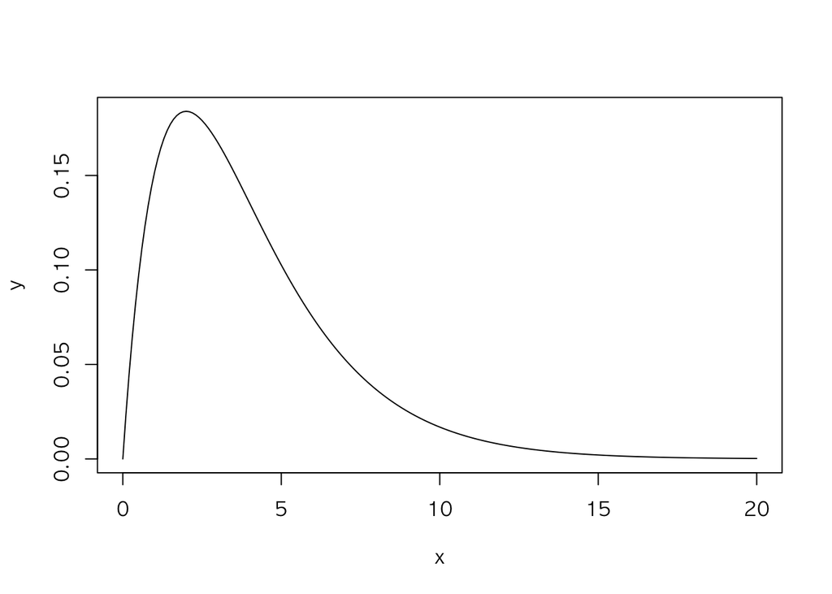

```r
x <- seq(0, 20 , 0.1)
y <- dchisq(x, 4)
plot(x,y, type = 'l')
```

## 2. 다음의 확률을 구하세요.

$$P(3 \leq X \leq 5)$$

```r
pchisq(5, 4) - pchisq(3, 4)
```

```
## [1] 0.2705279
```

## 3. 자유도가 4인 카이제곱분포에서 크기가 1000인 표본을 뽑은 후, 히스토그램을 그려보세요.

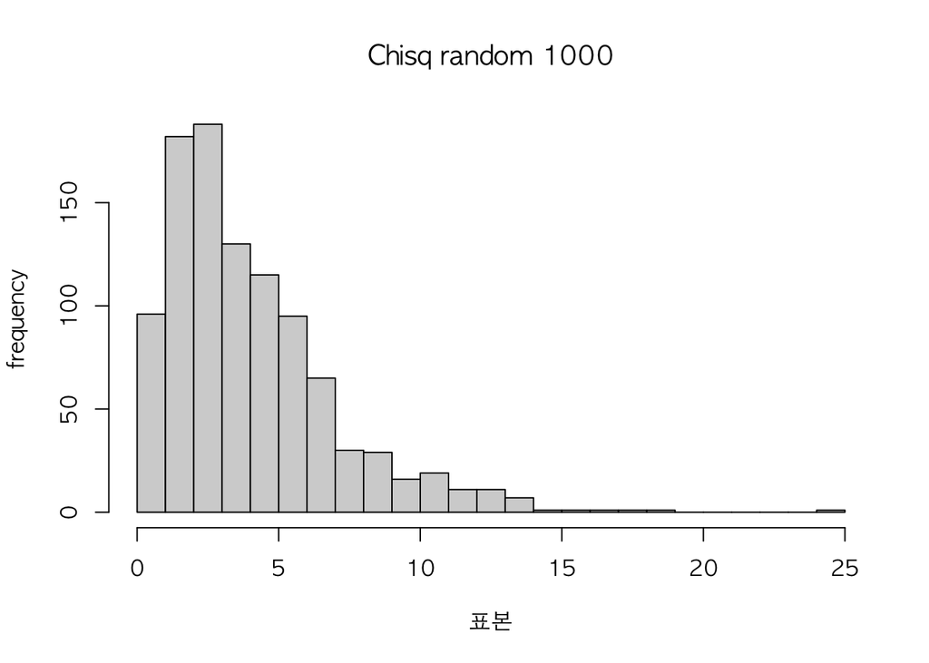

```r
set.seed(2023)
a <- rchisq(1000,4)
hist(a, breaks = 30,prob = FALSE,  main = 'Chisq random 1000' , xlab = '표본', ylab = 'frequency')
```

## 4. 자유도 4인 카이제곱 분포를 따르는 확률변수에서 나올 수 있는 값 중 상위 5%에 해당하는 값은 얼마?

```r
qchisq(0.95, 4)
```

```
## [1] 9.487729
```

## 5. 3번에서 뽑힌 표본값들 중 상위 5%에 위치한 표본의 값은 얼마인가?

```r
quantile(a, 0.95)
```

```
##      95%
## 10.28894
```

> 같은 방법으로 500개의 $s^2$ 를 발생시킨다.  
> 발생한 500개의 $s^2$ 들 각각에 4.75를 곱하고, 그것들의 히스토그램을 그려라(prob = TRUE).  
> 위에서 그린 히스토그램에 자유도가 19인 카이제곱분포 확률밀도함수를 겹쳐 그려라.

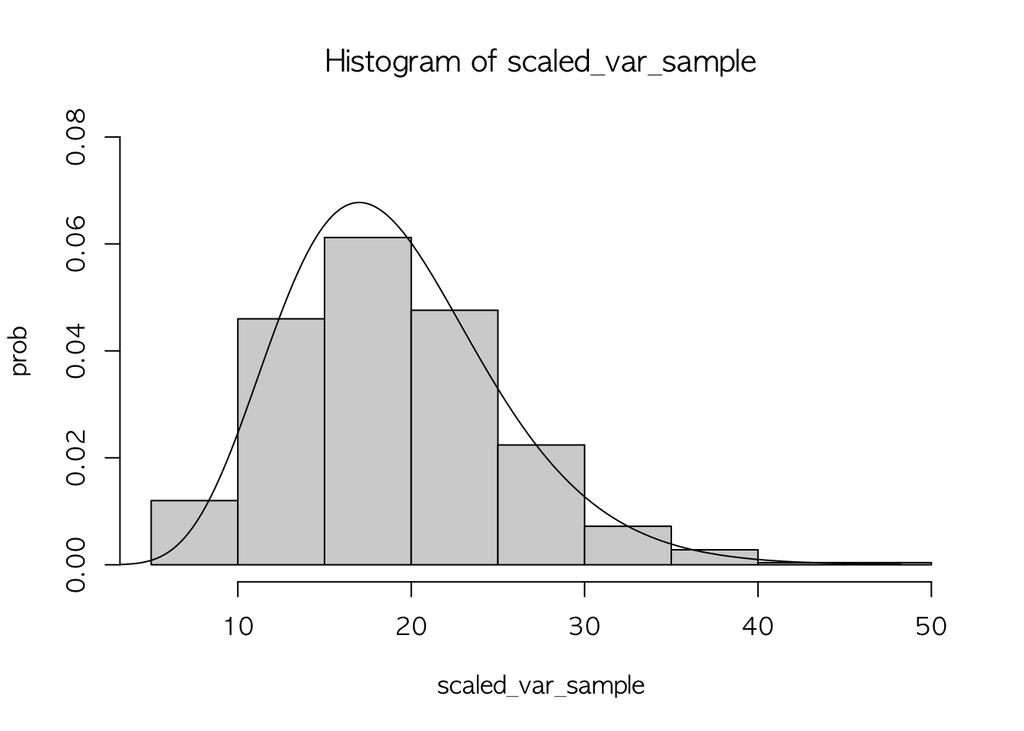

```r
set.seed(2023)

n <- 20
num_sample <- 500 # list 공간 크기
var_sample <- numeric(num_sample) # list 500개 공간 만듦

for (i in 1:num_sample) {
  x <- rnorm(n, 30, 2)
  var_sample[i] <- var(x) # list 에 넣음
}

scaled_var_sample <- var_sample * 4.75

hist(scaled_var_sample, prob = TRUE, ylim = c(0,0.08), ylab = 'prob')

x <- seq(0, max(scaled_var_sample), length.out = 1000)
pdf_chi19 <- dchisq(x, df = 19)
lines(x, pdf_chi19)
```

# 신뢰구간 구하기

> 16명을 무작위로 선별하여 몸무게 측정한 데이터, 이 데이터 이용하여 전체 몸무게 평균을 예측하고자한다. (정규분포를 따른다.)

## 1. 모평균에 대한 95% 신뢰구간을 구하세요. (모분산을 모를때)

```r
x <- c(71.2,62.2,53.2,70.1,65.7,82.9,62.9,82,68,67.3,75.3,67.9,77.6,78.6,66,79)
mean <- mean(x)
se <- sd(x)/sqrt(16)

lower <- round(mean - qt(0.975, 15)*se, 3)
upper <- round(mean + qt(0.975, 15)*se, 3)

c(lower, upper)
```

```
## [1] 66.289 74.948
```

## 2. 작년 표준편차는 6이다. 이 정보를 이번년 분포의 표준편차로 대체하여 모평균에 대한 90% 신뢰구간을 구하세요. (모분산을 알때)

**모표준편차를 알떄는 t분포가 아니라 z분포(표준정규분포)로 계산한다.**

```r
sd_pre <- 6
se_pre <- 6/sqrt(16)

lower_pre <- qnorm(0.05,mean,6/4)
upper_pre <- qnorm(0.95,mean,6/4)

c(lower_pre, upper_pre)
```

```
## [1] 68.15147 73.08603
```